# Midterm

Srishti Patil

2024-11-04

Import Data • Correctly import the data.

```r
library(ggplot2)
library(fpp)
library(fpp2)
library(forecast)

#importing data
library(readr)
salesData <- read_csv("C:/Users/Srishti/Desktop/FALL24/BF/Midterm/sales.csv")
# Adding Headers to all the columns in the Data File
colnames(salesData) <- c("date", "sales")
head(salesData)
```

```
## # A tibble: 6 × 2
##   date   sales
##   <chr>  <dbl>
## 1 2/1/20 1322.
## 2 3/1/20 1422.
## 3 4/1/20 1442.
## 4 5/1/20 1797.
## 5 6/1/20 1645.
## 6 8/1/20 1730.
```

Plot and Inference • Show a time series plot. • Please summarize your observations of the time series plot

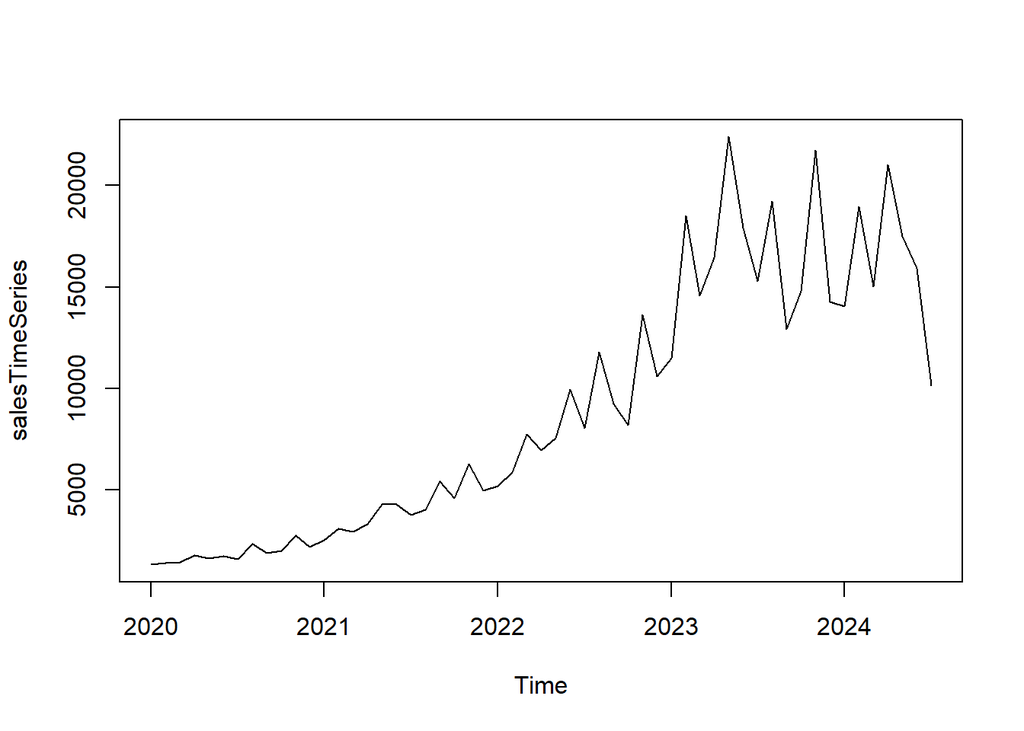

```r
salesTimeSeries <- ts(salesData$sales, frequency = 12, start = c(2020,1))
plot(salesTimeSeries)
```

Summary of the plot: -In the given plot we can see that there’s significant increase in the sales over the years from 2020 to 2024. -Plot shows that the sales start is low level in 2020 and rise gradually and evidently fluctuate from 2023 suggesting seasonality and cyclical patterns. -Sales starts declining from around 2024.

Central Tendency • What are the min, max, mean, median, 1st, and 3rd Quartile values of the times series? • Show the box plot. • Can you summarize your observation about the time series from the summary stats and box plot?

```r
summary(salesTimeSeries)
```

```
##    Min. 1st Qu.  Median    Mean 3rd Qu.    Max.
##    1322    3005    7540    8885   14419   22397
```

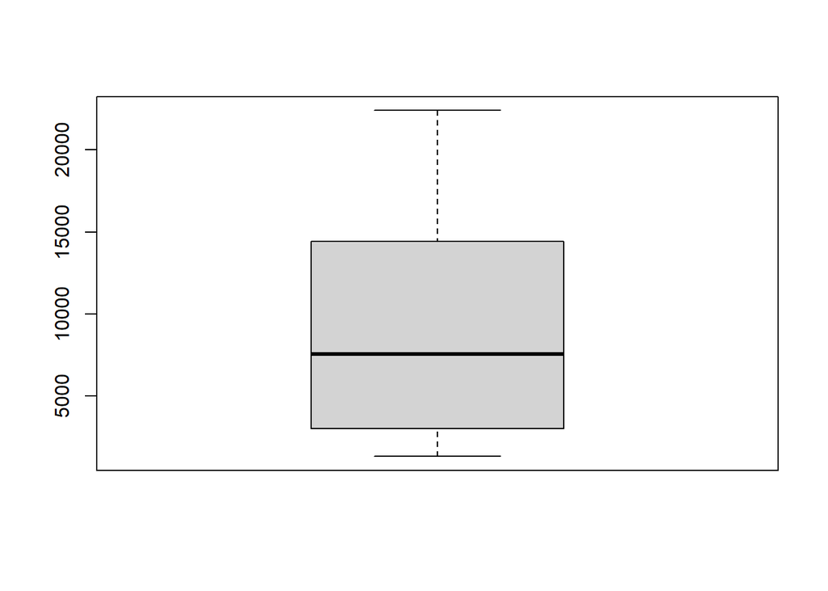

```r
boxplot(salesTimeSeries)
```

Min: 1322 1st Quartile: 3005 Median: 7540 Mean: 8885 3rd Quartile: 14419 Max: 22397

-As shown by the boxplot, the sales varies significantly from 1322 to 22397. -The median being lower than the mean suggests a right-skewed distribution showing there are some high sales values pulling the mean upwards -The IQR is 11414 which shows a wide spread in the middle 50% of the data.

Decomposition • Plot the decomposition of the time series.

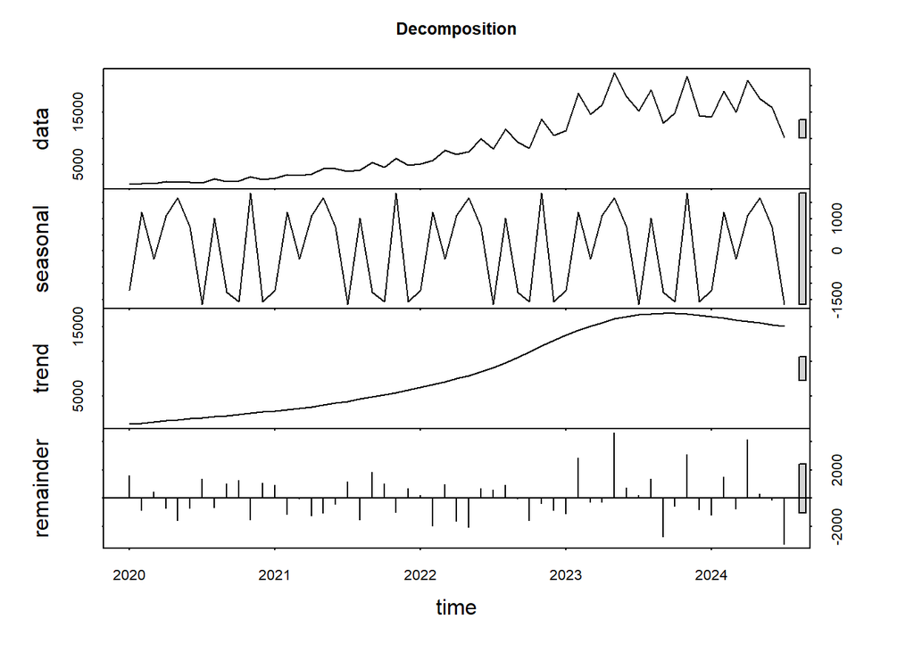

```r
#Using STL decomposition
decomposition_stl <- stl(salesTimeSeries,s.window ="periodic")
plot(decomposition_stl, main = 'Decomposition')
```

• Is the time series seasonal?

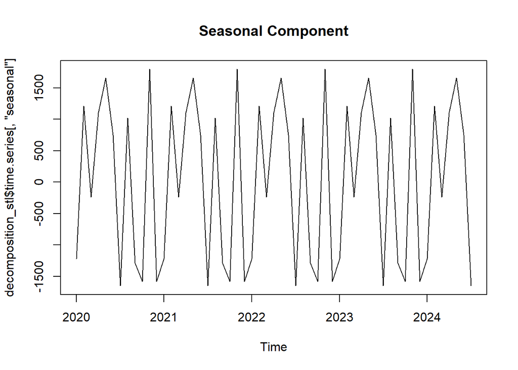

```r
#seasonal component
plot(decomposition_stl$time.series[, "seasonal"], main="Seasonal Component")
```

YES, looking at the repeating patterns in seasonal component we can see that the time series is seasonal.

• Is the decomposition additive or multiplicative?

```r
decompose <- decompose(salesTimeSeries)
decompose$type
```

```
## [1] "additive"
```

The consistancy in the scale of seasonal and reminder components suggests that the decompositon is additive.

• If seasonal, what are the values of the seasonal monthly indices?

```r
decompose$figure
```

```
##  [1] -1586.55747  1044.91532   -81.27967    64.01748  2130.90426  1015.30031
##  [7]  -838.64344  1035.33905 -1283.52221 -1589.13896  1750.09203 -1661.42670
```

• For which month is the time series value high, and for which month is it low?

- May has the highest value
- December has the lowest value

• Can you think of the reason behind the high and low values in those months?

-High demand in May can be due to seasonal demand. -It can also by because of increased healthcare campaigns and promotional activities in summers -Lowest value in December can be because of the holiday seasons. - Also, as insurance policies or benefits can often reset at the start of the tear hence people might hold on to their December purchase till January.

• Show the plot for time series adjusted for seasonality. Overlay this with the line for actuals? Does seasonality have big fluctuations in the value of time series?

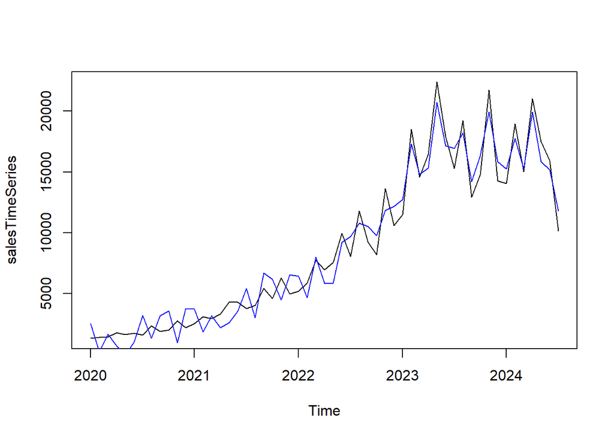

```r
plot(salesTimeSeries)
lines(seasadj(decomposition_stl), main = "Plot of seasonal adj", col="Blue")
```

The seasonality have big fluctuations in the value of time series. The differences in peaks and dips in the seasonally adjusted series and original series shows that due to seasonal effect the variation happened significantly which is smoothed in the blue line after we do adjustments in seasonality.

Naïve Method • Output

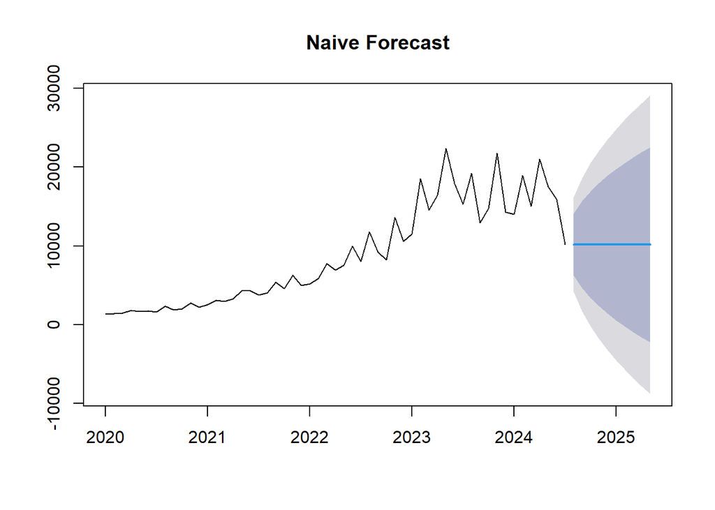

```r
naiveMethodSales = naive(salesTimeSeries)
plot(naiveMethodSales, main = "Naive Forecast")
```

```r
attributes(naiveMethodSales)
```

```
## $names
##  [1] "method"    "model"     "lambda"    "x"         "fitted"    "residuals"
##  [7] "series"    "mean"      "level"     "lower"     "upper"
##
## $class
## [1] "forecast"
```

• Perform Residual Analysis for this technique. o Do a plot of residuals. What does the plot indicate? o Do a Histogram plot of residuals. What does the plot indicate? o Do a plot of fitted values vs. residuals. What does the plot indicate? o Do a plot of actual values vs. residuals. What does the plot indicate? o Do an ACF plot of the residuals? What does this plot indicate?

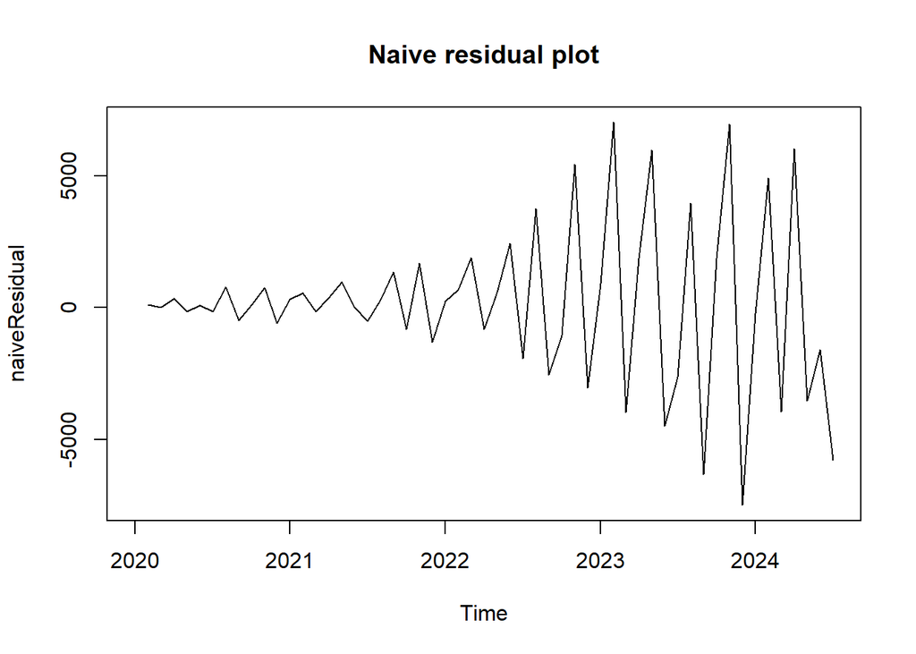

```r
#Plot of residual
naiveResidual <- naiveMethodSales$residuals
plot(naiveResidual, main="Naive residual plot")
```

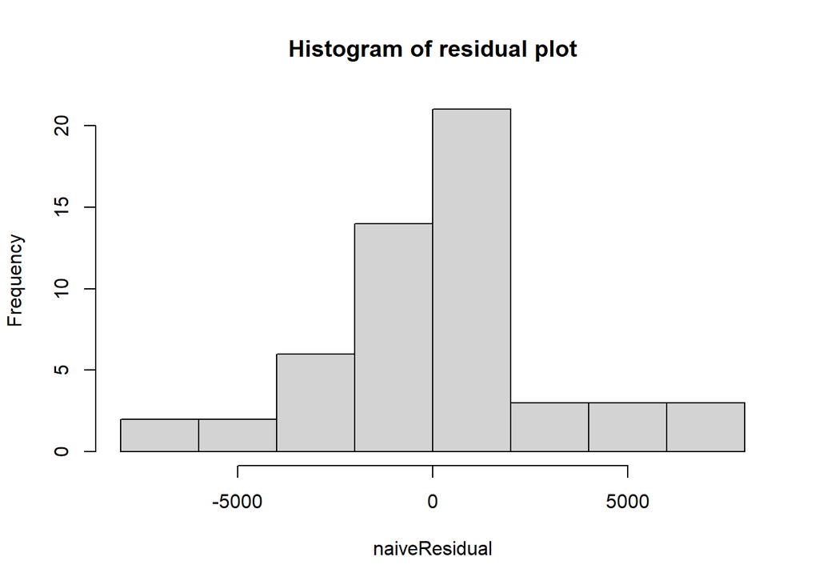

```r
#Histogram plot of residuals
hist(naiveResidual, main="Histogram of residual plot")
```

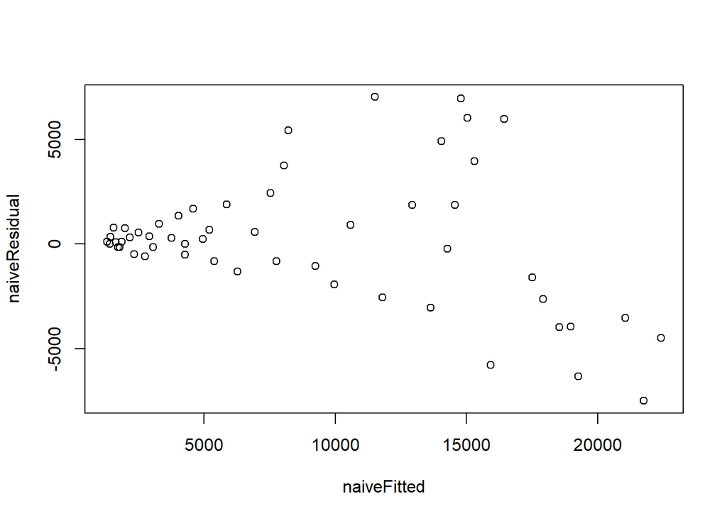

```r
#plot of fitted values vs. residuals
naiveFitted <- naiveMethodSales$fitted
plot(naiveFitted, naiveResidual, xy.labels = FALSE,xy.lines = FALSE)
```

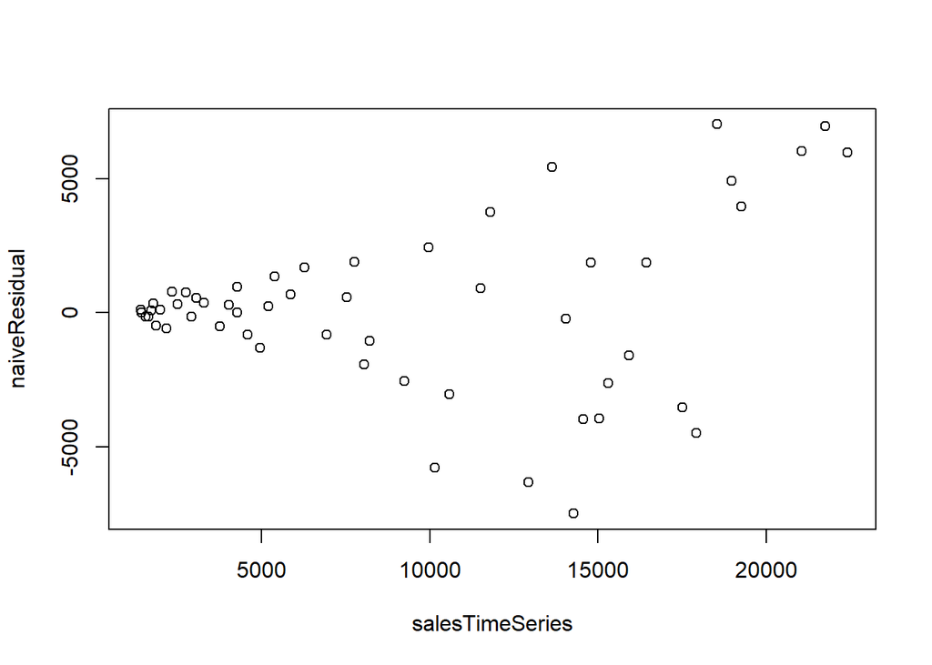

```r
#plot of actual values vs. residuals

plot(salesTimeSeries, naiveResidual,  xy.labels = FALSE,xy.lines = FALSE)
```

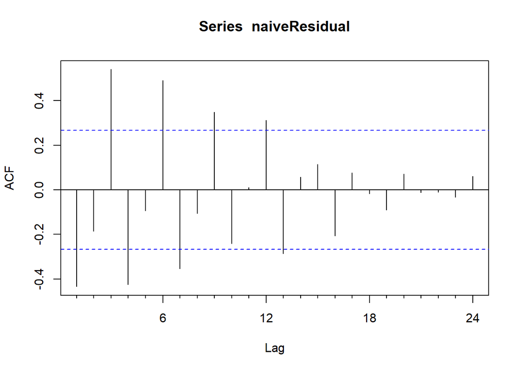

```r
#ACF plot of the residuals
Acf(naiveResidual)
```

```r
# measures of accuracy
naiveAccuracy<-accuracy(naiveMethodSales)
naiveAccuracy
```

```
##                    ME     RMSE     MAE       MPE     MAPE      MASE       ACF1
## Training set 163.5141 3057.345 2140.14 0.9005935 20.25086 0.4657811 -0.4335285
```

```r
#forecast
naiveforecast <- forecast(naiveMethodSales)
naiveforecast
```

```
##          Point Forecast      Lo 80    Hi 80      Lo 95    Hi 95
## Aug 2024       10151.93  6233.7881 14070.08  4159.6475 16144.22
## Sep 2024       10151.93  4610.8394 15693.03  1677.5616 18626.30
## Oct 2024       10151.93  3365.5070 16938.36  -227.0099 20530.88
## Nov 2024       10151.93  2315.6433 17988.22 -1832.6379 22136.50
## Dec 2024       10151.93  1390.6947 18913.17 -3247.2246 23551.09
## Jan 2025       10151.93   554.4774 19749.39 -4526.1088 24829.97
## Feb 2025       10151.93  -214.5039 20518.37 -5702.1641 26006.03
## Mar 2025       10151.93  -930.2542 21234.12 -6796.8097 27100.68
## Apr 2025       10151.93 -1602.5016 21906.37 -7824.9234 28128.79
## May 2025       10151.93 -2238.3290 22542.19 -8797.3374 29101.20
```

```r
accuracy(naiveforecast)
```

```
##                    ME     RMSE     MAE       MPE     MAPE      MASE       ACF1
## Training set 163.5141 3057.345 2140.14 0.9005935 20.25086 0.4657811 -0.4335285
```

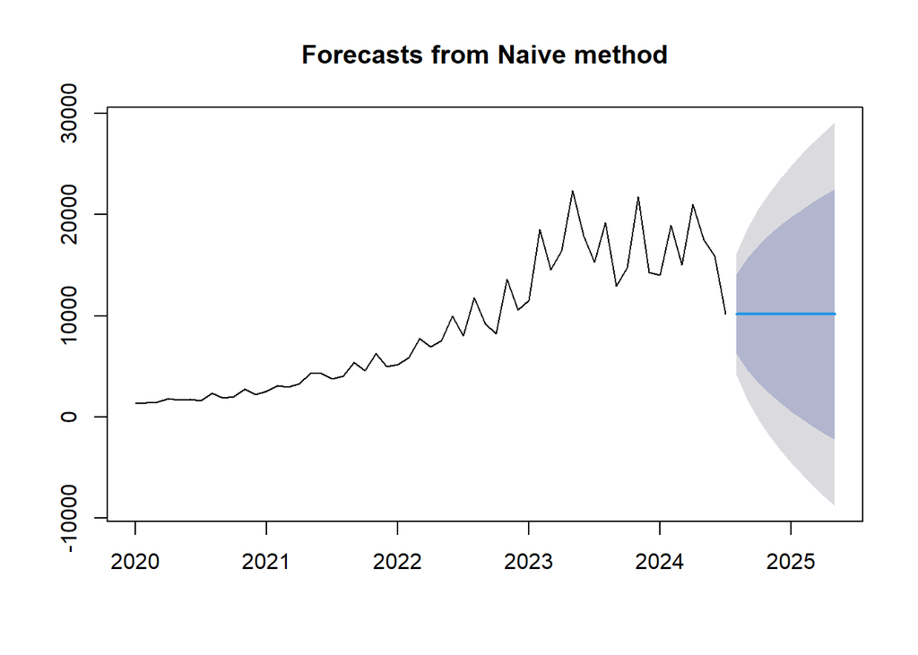

```r
plot(naiveforecast)
```

• Print the five measures of accuracy for this forecasting technique • Forecast 4 o Time series value for next year. Show table and plot • Summarize this forecasting technique o How good is the accuracy?

o What does it predict the time series value will be in one year? Remain steady with a Point Forecast of 10,151.93 for each month

o Other observation -The model shows moderate accuracy, with reasonable but not exceptional forecasting performance. It captures the trend to some extent but could be improved, particularly for handling high-value fluctuations and residual patterns.

Simple Moving Averages • Plot the graph for the time series. • Show the Simple Moving average of order three on the plot above in Red • Show the Simple Moving average of order six on the plot above in Blue • Show the Simple Moving average of order nine on the plot above in Green • (Bonus) show the forecast for the next 12 months using one of the simple average orders that you feel works best for time series • What are your observations of the plot as the moving average order goes up?

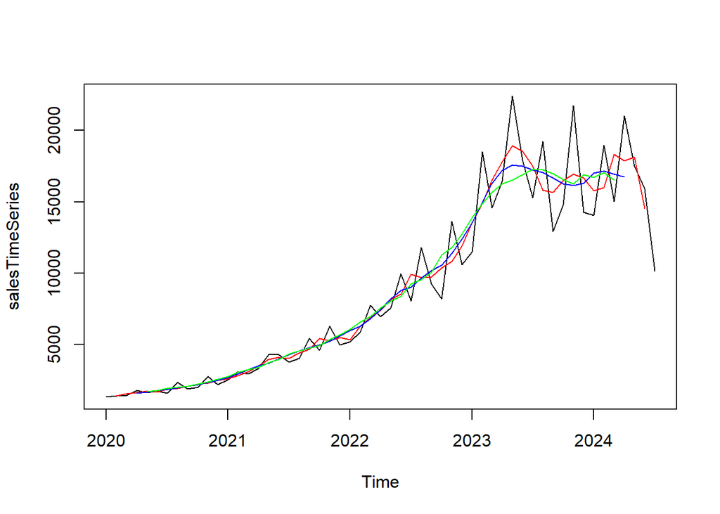

```r
#Moving Avg
MAforecast1 = ma(salesTimeSeries,order=3)
MAforecast2 = ma(salesTimeSeries,order=6)
MAforecast3 = ma(salesTimeSeries,order=9)

plot(salesTimeSeries)
lines(MAforecast1, col="red")
lines(MAforecast2, col="blue")
lines(MAforecast3, col="green")
```

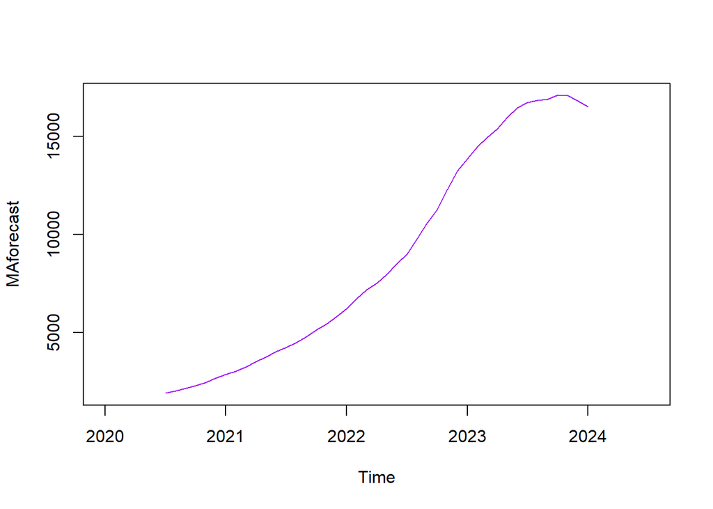

```r
MAforecast <- ma(salesTimeSeries,12)
plot(MAforecast)
lines(MAforecast, col="purple")
```

Simple Smoothing • Perform a simple smoothing forecast for the next 12 months for the time series. o What is the value of alpha? What does that value signify?

```
alpha = 0.432
Alpha specifies the coefficient for the level smoothing. Values near 1.0 mean that the latest value has more weight.
```

o What is the value of the initial state? l = 1446.3503

o What is the value of sigma? What does the sigma signify? sigma: 2627.533 Sigma defines the variance in the forecast predicted.

• Perform Residual Analysis for this technique. o Do a plot of residuals. What does the plot indicate? o Do a Histogram plot of residuals. What does the plot indicate? o Do a plot of fitted values vs. residuals. What does the plot indicate? o Do a plot of actual values vs. residuals. What does the plot indicate? o Do an ACF plot of the residuals? What does this plot indicate? • Print the five measures of accuracy for this forecasting technique • Forecast o Time series value for next year. Show table and plot • Summarize this forecasting technique o How good is the accuracy? o What does it predict the time series value will be in one year? o Other observation

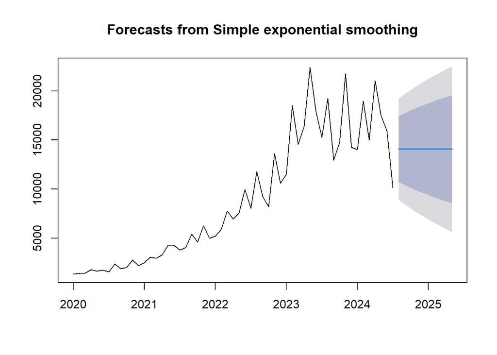

```r
#simple smoothing
simplesmoothing <- ses(salesTimeSeries)
plot(simplesmoothing)
```

```r
summary(simplesmoothing)
```

```
##
## Forecast method: Simple exponential smoothing
##
## Model Information:
## Simple exponential smoothing
##
## Call:
## ses(y = salesTimeSeries)
##
##   Smoothing parameters:
##     alpha = 0.432
##
##   Initial states:
##     l = 1446.3503
##
##   sigma:  2627.533
##
##      AIC     AICc      BIC
## 1090.484 1090.955 1096.506
##
## Error measures:
##                    ME     RMSE      MAE      MPE     MAPE      MASE       ACF1
## Training set 531.5383 2579.317 1637.119 5.938042 15.73922 0.3563034 -0.1467358
##
## Forecasts:
##          Point Forecast     Lo 80    Hi 80    Lo 95    Hi 95
## Aug 2024       14074.69 10707.370 17442.01 8924.819 19224.56
## Sep 2024       14074.69 10406.638 17742.74 8464.889 19684.49
## Oct 2024       14074.69 10128.760 18020.62 8039.911 20109.47
## Nov 2024       14074.69  9869.202 18280.17 7642.953 20506.42
## Dec 2024       14074.69  9624.759 18524.62 7269.109 20880.27
## Jan 2025       14074.69  9393.061 18756.32 6914.758 21234.62
## Feb 2025       14074.69  9172.302 18977.07 6577.136 21572.24
## Mar 2025       14074.69  8961.064 19188.31 6254.075 21895.30
## Apr 2025       14074.69  8758.213 19391.16 5943.841 22205.54
## May 2025       14074.69  8562.822 19586.55 5645.017 22504.36
```

```r
attributes(simplesmoothing)
```

```
## $names
##  [1] "model"     "mean"      "level"     "x"         "upper"     "lower"
##  [7] "fitted"    "method"    "series"    "residuals"
##
## $class
## [1] "forecast"
```

```r
#accuracy
accuracy(simplesmoothing)
```

```
##                    ME     RMSE      MAE      MPE     MAPE      MASE       ACF1
## Training set 531.5383 2579.317 1637.119 5.938042 15.73922 0.3563034 -0.1467358
```

```r
simplesmoothingaccuracy <- ses(salesTimeSeries,12)


simplesmoothingaccuracy
```

```
##          Point Forecast     Lo 80    Hi 80    Lo 95    Hi 95
## Aug 2024       14074.69 10707.370 17442.01 8924.819 19224.56
## Sep 2024       14074.69 10406.638 17742.74 8464.889 19684.49
## Oct 2024       14074.69 10128.760 18020.62 8039.911 20109.47
## Nov 2024       14074.69  9869.202 18280.17 7642.953 20506.42
## Dec 2024       14074.69  9624.759 18524.62 7269.109 20880.27
## Jan 2025       14074.69  9393.061 18756.32 6914.758 21234.62
## Feb 2025       14074.69  9172.302 18977.07 6577.136 21572.24
## Mar 2025       14074.69  8961.064 19188.31 6254.075 21895.30
## Apr 2025       14074.69  8758.213 19391.16 5943.841 22205.54
## May 2025       14074.69  8562.822 19586.55 5645.017 22504.36
## Jun 2025       14074.69  8374.125 19775.25 5356.428 22792.95
## Jul 2025       14074.69  8191.476 19957.90 5077.092 23072.29
```

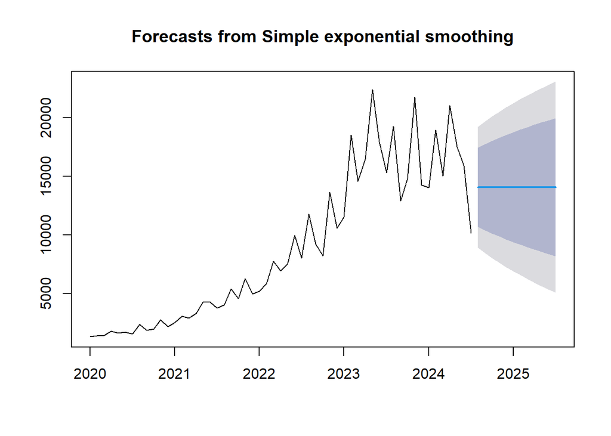

```r
plot(simplesmoothingaccuracy)
```

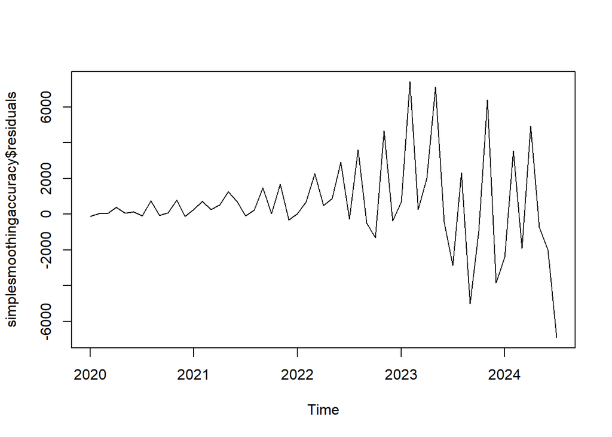

```r
plot(simplesmoothingaccuracy$residuals)
```

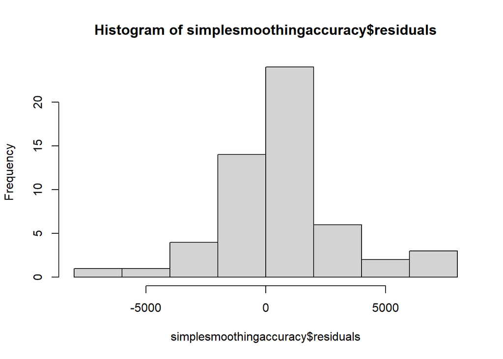

```r
hist(simplesmoothingaccuracy$residuals)
```

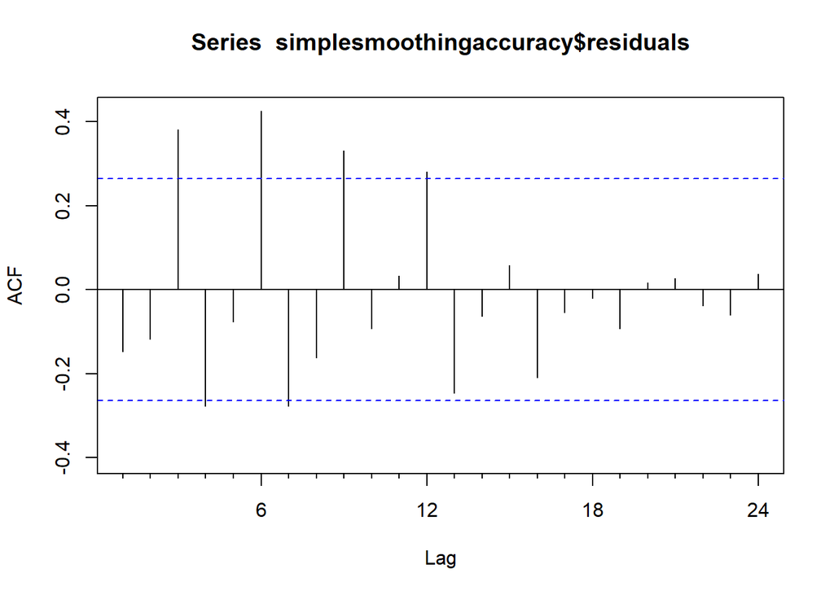

```r
Acf(simplesmoothingaccuracy$residuals)
```

```r
forecast(simplesmoothingaccuracy)
```

```
##          Point Forecast     Lo 80    Hi 80    Lo 95    Hi 95
## Aug 2024       14074.69 10707.370 17442.01 8924.819 19224.56
## Sep 2024       14074.69 10406.638 17742.74 8464.889 19684.49
## Oct 2024       14074.69 10128.760 18020.62 8039.911 20109.47
## Nov 2024       14074.69  9869.202 18280.17 7642.953 20506.42
## Dec 2024       14074.69  9624.759 18524.62 7269.109 20880.27
## Jan 2025       14074.69  9393.061 18756.32 6914.758 21234.62
## Feb 2025       14074.69  9172.302 18977.07 6577.136 21572.24
## Mar 2025       14074.69  8961.064 19188.31 6254.075 21895.30
## Apr 2025       14074.69  8758.213 19391.16 5943.841 22205.54
## May 2025       14074.69  8562.822 19586.55 5645.017 22504.36
## Jun 2025       14074.69  8374.125 19775.25 5356.428 22792.95
## Jul 2025       14074.69  8191.476 19957.90 5077.092 23072.29
```

Holt-Winters • Perform Holt-Winters forecast for the next 12 months for the time series. o What is the value of alpha? What does that value signify?

```
alpha = 0.2948
```

Alpha specifies the coefficient for the level smoothing in Holtwinters.

o What is the value of beta? What does that value signify? beta = 0.0894

Beta specifies the coefficient for the trend smoothing in Holtwinters.

o What is the value of gamma? What does that value signify? gamma = 1e-04

Gamma specifies the coefficient for the seasonal smoothing in Holtwinters.

o What is the value of initial states for the level, trend, and seasonality? What do these values signify? Initial states: l = 446.9245 b = 354.2206 s = -1661.38 1750.277 -1588.956 -1283.547 1035.267 -838.3166 1015.053 2130.941 124.725 -81.034 1045.168 -1648.196

o What is the value of sigma? What does the sigma signify? sigma: 2420.948 Sigma defines the variance of the forecast values.

• Perform Residual Analysis for this technique. o Do a plot of residuals. What does the plot indicate? o Do a Histogram plot of residuals. What does the plot indicate? o Do a plot of fitted values vs. residuals. What does the plot indicate? o Do a plot of actual values vs. residuals. What does the plot indicate? o Do an ACF plot of the residuals? What does this plot indicate? • Print the five measures of accuracy for this forecasting technique • Forecast 5 o Time series value for next year. Show table and plot • Summarize this forecasting technique o How good is the accuracy? The model’s accuracy shows moderate error levels, with a Mean Absolute Percentage Error indicating that forecasts deviate from average from actual values. The low Autocorrelation suggests minimal correlation in residuals, which is a positive sign for forecast reliability, though the high RMSE points to notable prediction errors.

o What does it predict the time series value will be in one year? o Other observation

```r
holtsWinter <- hw(salesTimeSeries, seasonal = "additive")
plot(holtsWinter)
holtsWinter$model
```

[output not shown]

```
## Holt-Winters' additive method
##
## Call:
## hw(y = salesTimeSeries, seasonal = "additive")
##
##   Smoothing parameters:
##     alpha = 0.2948
##     beta  = 0.0894
##     gamma = 1e-04
##
##   Initial states:
##     l = 446.9245
##     b = 354.2206
##     s = -1661.38 1750.277 -1588.956 -1283.547 1035.267 -838.3166
##            1015.053 2130.941 124.725 -81.034 1045.168 -1648.196
##
##   sigma:  2420.948
##
##      AIC     AICc      BIC
## 1092.606 1109.147 1126.731
```

```r
summary(holtsWinter)
```

```
##
## Forecast method: Holt-Winters' additive method
##
## Model Information:
## Holt-Winters' additive method
##
## Call:
## hw(y = salesTimeSeries, seasonal = "additive")
##
##   Smoothing parameters:
##     alpha = 0.2948
##     beta  = 0.0894
##     gamma = 1e-04
##
##   Initial states:
##     l = 446.9245
##     b = 354.2206
##     s = -1661.38 1750.277 -1588.956 -1283.547 1035.267 -838.3166
##            1015.053 2130.941 124.725 -81.034 1045.168 -1648.196
##
##   sigma:  2420.948
##
##      AIC     AICc      BIC
## 1092.606 1109.147 1126.731
##
## Error measures:
##                     ME     RMSE      MAE       MPE     MAPE      MASE
## Training set -217.9273 2038.621 1651.836 -2.664094 31.45275 0.3595064
##                     ACF1
## Training set -0.02756788
##
## Forecasts:
##          Point Forecast       Lo 80    Hi 80       Lo 95    Hi 95
## Aug 2024    14883.19268  11780.6226 17985.76  10138.2212 19628.16
## Sep 2024    11847.42600   8523.7910 15171.06   6764.3649 16930.49
## Oct 2024    10825.07160   7191.2033 14458.94   5267.5496 16382.59
## Nov 2024    13447.36550   9415.6105 17479.12   7281.3283 19613.40
## Dec 2024     9318.74180   4807.5934 13829.89   2419.5357 16217.95
## Jan 2025     8615.17410   3551.0854 13679.26    870.3188 16360.03
## Feb 2025    10591.31365   4908.6724 16273.95   1900.4639 19282.16
## Mar 2025     8747.94423   2388.1901 15107.70   -978.4603 18474.35
## Apr 2025     8237.34871   1147.8538 15326.84  -2605.0981 19079.80
## May 2025     9525.70813   1658.7157 17392.70  -2505.8185 21557.23
## Jun 2025     7693.10214   -995.1732 16381.38  -5594.4683 20980.67
## Jul 2025     5122.60137  -4427.4967 14672.70  -9483.0132 19728.22
## Aug 2025     6279.73465  -4170.1791 16729.65  -9702.0293 22261.50
## Sep 2025     3243.96797  -8141.2680 14629.20 -14168.2479 20656.18
## Oct 2025     2221.61357 -10132.7164 14575.94 -16672.7037 21115.93
## Nov 2025     4843.90747  -8511.6933 18199.51 -15581.7212 25269.54
## Dec 2025      715.28377 -13672.3902 15102.96 -21288.7648 22719.33
## Jan 2026       11.71607 -15437.6369 15461.07 -23616.0304 23639.46
## Feb 2026     1987.85562 -14551.7291 18527.44 -23307.2564 27282.97
## Mar 2026      144.48620 -17512.9483 17801.92 -26860.2295 27149.20
## Apr 2026     -366.10932 -19168.1746 18435.96 -29121.3867 28389.17
## May 2026      922.25010 -19050.4717 20894.97 -29623.3919 31467.89
## Jun 2026     -910.35589 -22079.0741 20258.36 -33285.1166 31464.40
## Jul 2026    -3480.85666 -25870.2841 18908.57 -37722.5310 30760.82
```

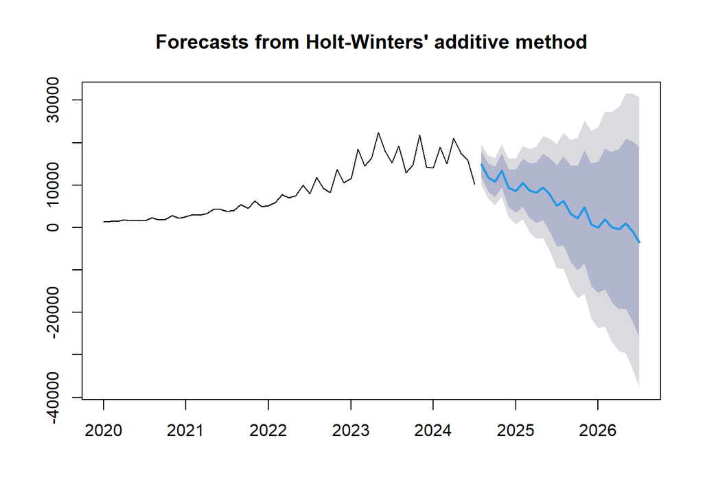

```r
holtsWinter1 <- hw(salesTimeSeries,12)
plot(holtsWinter)
```

```r
print(holtsWinter)
```

```
##          Point Forecast       Lo 80    Hi 80       Lo 95    Hi 95
## Aug 2024    14883.19268  11780.6226 17985.76  10138.2212 19628.16
## Sep 2024    11847.42600   8523.7910 15171.06   6764.3649 16930.49
## Oct 2024    10825.07160   7191.2033 14458.94   5267.5496 16382.59
## Nov 2024    13447.36550   9415.6105 17479.12   7281.3283 19613.40
## Dec 2024     9318.74180   4807.5934 13829.89   2419.5357 16217.95
## Jan 2025     8615.17410   3551.0854 13679.26    870.3188 16360.03
## Feb 2025    10591.31365   4908.6724 16273.95   1900.4639 19282.16
## Mar 2025     8747.94423   2388.1901 15107.70   -978.4603 18474.35
## Apr 2025     8237.34871   1147.8538 15326.84  -2605.0981 19079.80
## May 2025     9525.70813   1658.7157 17392.70  -2505.8185 21557.23
## Jun 2025     7693.10214   -995.1732 16381.38  -5594.4683 20980.67
## Jul 2025     5122.60137  -4427.4967 14672.70  -9483.0132 19728.22
## Aug 2025     6279.73465  -4170.1791 16729.65  -9702.0293 22261.50
## Sep 2025     3243.96797  -8141.2680 14629.20 -14168.2479 20656.18
## Oct 2025     2221.61357 -10132.7164 14575.94 -16672.7037 21115.93
## Nov 2025     4843.90747  -8511.6933 18199.51 -15581.7212 25269.54
## Dec 2025      715.28377 -13672.3902 15102.96 -21288.7648 22719.33
## Jan 2026       11.71607 -15437.6369 15461.07 -23616.0304 23639.46
## Feb 2026     1987.85562 -14551.7291 18527.44 -23307.2564 27282.97
## Mar 2026      144.48620 -17512.9483 17801.92 -26860.2295 27149.20
## Apr 2026     -366.10932 -19168.1746 18435.96 -29121.3867 28389.17
## May 2026      922.25010 -19050.4717 20894.97 -29623.3919 31467.89
## Jun 2026     -910.35589 -22079.0741 20258.36 -33285.1166 31464.40
## Jul 2026    -3480.85666 -25870.2841 18908.57 -37722.5310 30760.82
```

```r
hwaccuracy<- accuracy(holtsWinter1)
hwaccuracy
```

```
##                     ME     RMSE      MAE       MPE     MAPE      MASE
## Training set -217.9273 2038.621 1651.836 -2.664094 31.45275 0.3595064
##                     ACF1
## Training set -0.02756788
```

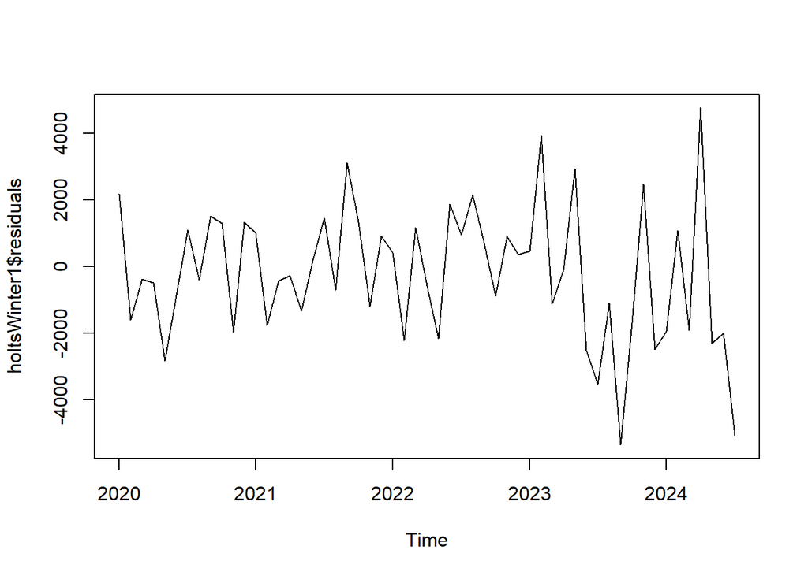

```r
plot(holtsWinter1$residuals)
```

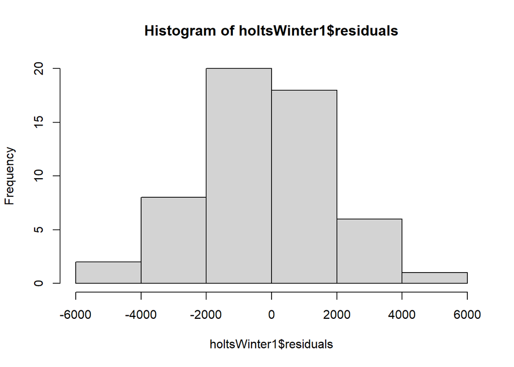

```r
hist(holtsWinter1$residuals)
```

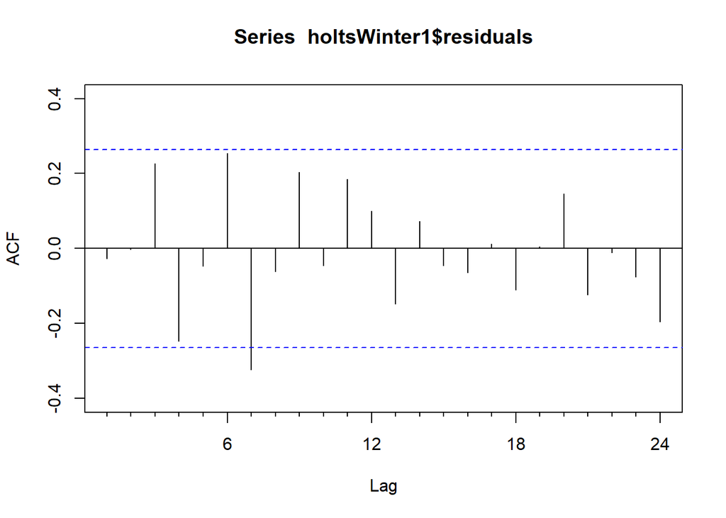

```r
Acf(holtsWinter1$residuals)
```

```r
forecast(holtsWinter1)
```

```
##          Point Forecast      Lo 80    Hi 80      Lo 95    Hi 95
## Aug 2024      14883.193 11780.6226 17985.76 10138.2212 19628.16
## Sep 2024      11847.426  8523.7910 15171.06  6764.3649 16930.49
## Oct 2024      10825.072  7191.2033 14458.94  5267.5496 16382.59
## Nov 2024      13447.365  9415.6105 17479.12  7281.3283 19613.40
## Dec 2024       9318.742  4807.5934 13829.89  2419.5357 16217.95
## Jan 2025       8615.174  3551.0854 13679.26   870.3188 16360.03
## Feb 2025      10591.314  4908.6724 16273.95  1900.4639 19282.16
## Mar 2025       8747.944  2388.1901 15107.70  -978.4603 18474.35
## Apr 2025       8237.349  1147.8538 15326.84 -2605.0981 19079.80
## May 2025       9525.708  1658.7157 17392.70 -2505.8185 21557.23
## Jun 2025       7693.102  -995.1732 16381.38 -5594.4683 20980.67
## Jul 2025       5122.601 -4427.4967 14672.70 -9483.0132 19728.22
```

Observations: The forecast shows a general decline in sales from August 2024 to May 2025, with increasing uncertainty over time, as indicated by the widening confidence intervals. Negative lower bounds in early 2025 highlight high forecast volatility and potential model limitations for long-term predictions.

Conclusion • Summarize your analysis of time series value over the time period.

• Based on your analysis and forecast above, do you think the value of the time series will increase, decrease, or stay flat over the next year? How about the next 2 years? according to my analysis the forecast will decrease. evenafter 2 years the forecast will decrease.

• Rank forecasting methods for this time series based on historical values. The best forecasting method is holtswinter followed by simple smoothing then naive